# Upload your Sentinel policy set to HCP Terraform

- 5min
- |
- HCP Terraform
- Terraform

To enable Sentinel policy enforcement on your Terraform runs, you must upload your policy to your HCP Terraform organization. In this tutorial, you will create a new Sentinel policy set in your organization, configure a workspace to apply your policy, and trigger the Sentinel policy checks.

Note

HCP Terraform **Free** Edition includes one policy set of up to five policies. In HCP Terraform **Standard** Edition, you can connect a policy set to a version control repository or create policy set versions via the API. Refer to [HCP Terraform pricing](https://www.hashicorp.com/products/terraform/pricing) for details.

## Prerequisites

For this tutorial you will need:

- An HCP Terraform or Terraform Enterprise account
- Access to the `owners` group of your Terraform organization
- A [GitHub account](https://github.com/)
- An [AWS account to create example resources](https://aws.amazon.com/)

You should also be familiar with how to trigger HCP Terraform runs from VCS changes and destroy HCP Terraform workspaces.

## Fork the example repository

Fork the [example repository](https://github.com/hashicorp-education/learn-terraform-sentinel), which contains Terraform configuration to provision an EC2 instance.

[figure not shown]

## Create an HCP Terraform workspace

Navigate to your HCP Terraform organization and create a new VCS-backed workspace connected to your fork of the `learn-terraform-sentinel` repository.

## Configure workspace variables

Navigate to your `learn-terraform-sentinel` workspace's "Variables" page.

Define a variable called `instance_type` and set the value to `t2.large`.

When complete, your variable definitions will match the following:

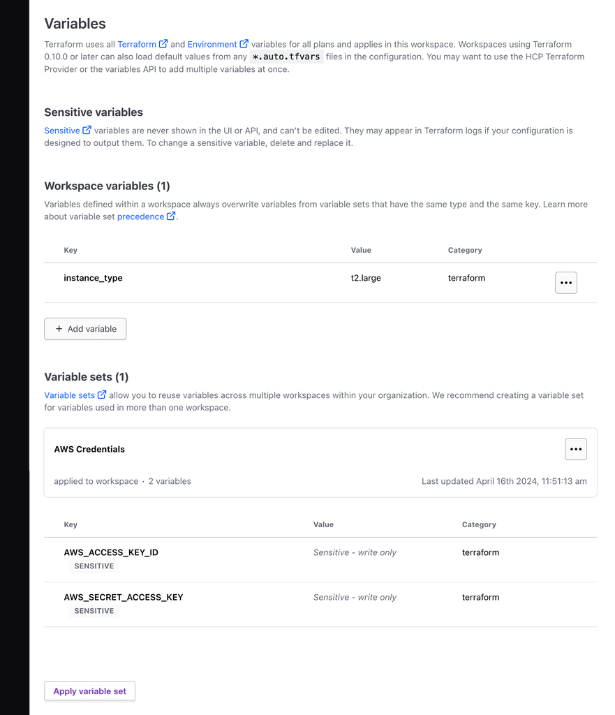

## Fork the Sentinel policy set repository

Now fork the [example policy repository](https://github.com/hashicorp-education/learn-sentinel-policy-upload), which contains a Sentinel policy and rule enforcement definition.

The `restrict-aws-instances-type-and-tag.sentinel` file contains a Sentinel policy that defines a `main` rule that consists of two other rules defining infrastructure requirements:

- The `mandatory_instance_tags` rule checks that all EC2 instances have a `Name` tag.
- The `instance_types_allowed` rule checks that EC2 instances are of type `t2.micro`, `t2.small`, or `t2.medium`.

Tip

To review the policy used in this tutorial and how to use Sentinel mock data when writing Sentinel policies in more detail, visit the Write a Sentinel Policy for a Terraform Deployment tutorial.

You must list all of the policies defined in the policy repository in the `sentinel.hcl` file. This file also sets the enforcement level for each policy, which specifies the behavior in the event of a policy failure. HCP Terraform evaluates the policies in the order they appear in this file.

This configuration contains one policy definition.

sentinel.hcl

```
policy "restrict-aws-instances-type-and-tag" {
  enforcement_level = "hard-mandatory"
}
```

Notice the configured `enforcement_level` for your policy. A policy can have one of three enforcement levels:

- **Advisory (default)**: The policy can fail. HCP Terraform records all failures in the audit log.
- **Soft mandatory**: In the event of failure, organization owners or users with override permissions can override the policy to let the run proceed. HCP Terraform records all overrides in the audit log.
- **Hard mandatory**: The policy must pass for the run to proceed.

## Connect the policy set

In the HCP Terraform UI, navigate to **Settings** > **Policy Sets**. Then, click on **Connect a new policy set** to create a new policy set.

[figure not shown]

Select your fork of the `learn-sentinel-policy-upload` repository as the source. For more information or for other VCS connection settings, visit our Trigger HCP Terraform runs from VCS changes tutorial.

Tip

The search bar for policy repositories is case sensitive.

HCP Terraform applies policy sets either across your organization, or to specific workspaces.

On the **Connect to VCS** page:

1. Select your GitHub VCS provider.
2. Select your forked `learn-sentinel-policy-upload` repository.
3. Click the **Next** button.

On the **Parameters** page, click the **Connect policy set** button to finish creating your policy set.

## Trigger a Sentinel Check

Navigate to your `learn-terraform-sentinel` workspace. Click on the **Actions** menu and select **Plan and apply (standard)**.

Because you set the `instance_type` variable to `t2.large`, this run will fail the policy check because it violates the `instance_types_allowed` rule. Terraform will not let you apply the plan.

[figure not shown]

Navigate to the workspace's **Variables** page and update the value of `instance_type` to `t2.small`. Save the variable.

Start another run. This time, Sentinel will validate the proposed changes and let you apply the plan.

[figure not shown]

Since this is the end of the tutorial, click **Discard Run**.

## Delete the policy set

Navigate back to your policy set under **Settings** > **Policy Sets**, then click **Delete policy set**. Confirm by clicking "Yes, delete policy set".

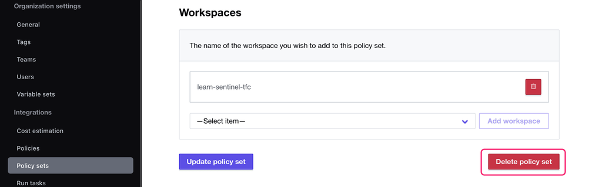

## Delete workspace

If you will continue with other policy tutorials, skip this step.

HCP Terraform does not charge per workspace, so you can keep the workspace if you will complete the remaining tutorials later. To delete it, navigate to your workspace's **Settings**, then select **Destruction and Deletion** and follow the prompts to delete the workspace.

## Next steps

You have now uploaded a Sentinel policy set to HCP Terraform and triggered policy failures and passes. To learn more about Sentinel, review the following resources:

- Learn how to Generate Mock Policy Data
- Review how to Write a Sentinel Policy
- Review how to Test a Sentinel Policy
- Review [Sentinel and HCP Terraform documentation](https://developer.hashicorp.com/terraform/cloud-docs/workspaces/policy-enforcement/define-policies/custom-sentinel)
- [Experiment in the Sentinel Playground](https://play.sentinelproject.io/)
- Review [Sentinel Language Specification documentation](https://docs.hashicorp.com/sentinel/language/spec)
- Learn how to use policies from the Terraform registry